# Fundamentos de Pesquisa em Ciência da Computação 2

Relatório - Análise Descritiva e Inferência Estatística

28 de junho de 2018

Este relatório compreende a análise descritiva e a inferência estatística para uma amostra de refatoramentos detectados pelas ferramentas *RMiner* e *RefDiff*, fazendo parte do Anexo D do relato de replicação do experimento efetuado por Tsantalis et at.

### **1. Bibliotecas Utilizadas**

```r
library(tidyverse)
library(here)
library(dplyr)
library(kableExtra)
library(ggrepel)
library(boot) ##bootstraping e cálculo do intervalo de confiança
library(resample) ##permutação e cálculo do p-valor
library(coin)
theme_set(theme_bw())
```

### **2. Importação dos Dados**

```r
datasetRefactorings <- read_csv(here::here("data/ToolsRefactorings.csv"))

datasetExecutionTime <- read_csv(here::here("data/ToolsExecutionTime.csv"))

glimpse(datasetRefactorings)
```

```
## Observations: 20
## Variables: 7
## $ tool            <chr> "RefDiff", "RMiner", "RefDiff", "RMiner", "Ref...
## $ refactoringType <chr> "Extract Method", "Extract Method", "Extract S...
## $ TP              <int> 47, 46, 2, 2, 45, 44, 2, 4, 11, 11, 2, 2, 1, 1...
## $ FP              <int> 2, 4, 0, 0, 0, 0, 0, 8, 0, 113, 0, 26, 0, 2, 0...
## $ FN              <int> 3, 2, 0, 0, 0, 1, 2, 0, 2, 2, 0, 0, 0, 0, 0, 0...
## $ precision       <dbl> 95.9, 92.0, 100.0, 100.0, 100.0, 100.0, 100.0,...
## $ recall          <dbl> 94.0, 95.8, 100.0, 100.0, 100.0, 97.8, 50.0, 1...
```

```r
glimpse(datasetExecutionTime)
```

```
## Observations: 74
## Variables: 3
## $ Tool          <chr> "RefDiff", "RefDiff", "RefDiff", "RefDiff", "Ref...
## $ CommitId      <chr> "6cf596df183b3c3a38ed5dd9bb3b0100c6548ebb", "280...
## $ ExecutionTime <dbl> 6095.8, 606.5, 595.9, 1636.6, 683.2, 922.7, 2763...
```

A partir desses *datasets*, consideram-se 20 observações de refatoramentos detectados (*datasetRefactorings*) nas execuções das ferramentas *RMiner* e *RefDiff*, com base em 37 *commits* cada, cujos tempos de execução estão dispostos em *datasetExecutionTime*.

### **3. Análise Descritiva dos Dados**

A tabela 1 exibe a distribuição dos tipos de refatoramento detectados a partir da amostra de 425 refatoramentos, provenientes de 37 *commits*.

```r
valuesOfType = c("Move Attribute", "Pull Down Attribute", "Pull Up Attribute", " ", "Extract Method", "Inline Method", "Pull Up Method", "Rename Method", "Extract Superclass", "Move Class", "Rename Class", " ")
matrixVariable <- matrix(valuesOfType, nrow = 4, ncol = 3)
colnames(matrixVariable) <- c(" ", " ", " ")
kable(matrixVariable, caption = "Tabela 1 - Categorias de Refatoramentos Detectados") %>%
  kable_styling(bootstrap_options = "striped", full_width = F) %>%
  add_header_above(c("Atributo" = 1, "Método" = 1, "Tipo" = 1), line = FALSE)
```

Tabela 1 - Categorias de Refatoramentos Detectados

| Atributo | Método | Tipo |
| --- | --- | --- |
| Move Attribute | Extract Method | Extract Superclass |
| Pull Down Attribute | Inline Method | Move Class |
| Pull Up Attribute | Pull Up Method | Rename Class |
|  | Rename Method |  |

As figuras 1 a 3 exibem a distribuição da quantidade de TP (verdadeiros positivos), FP (falsos positivos) e FN (falsos negativos) por tipo de refatoramento para o *RefDiff* e *RMiner*.

```
## Observations: 2
## Variables: 2
## $ tool         <chr> "RefDiff", "RMiner"
## $ meanVariable <dbl> 12.6, 12.4
```

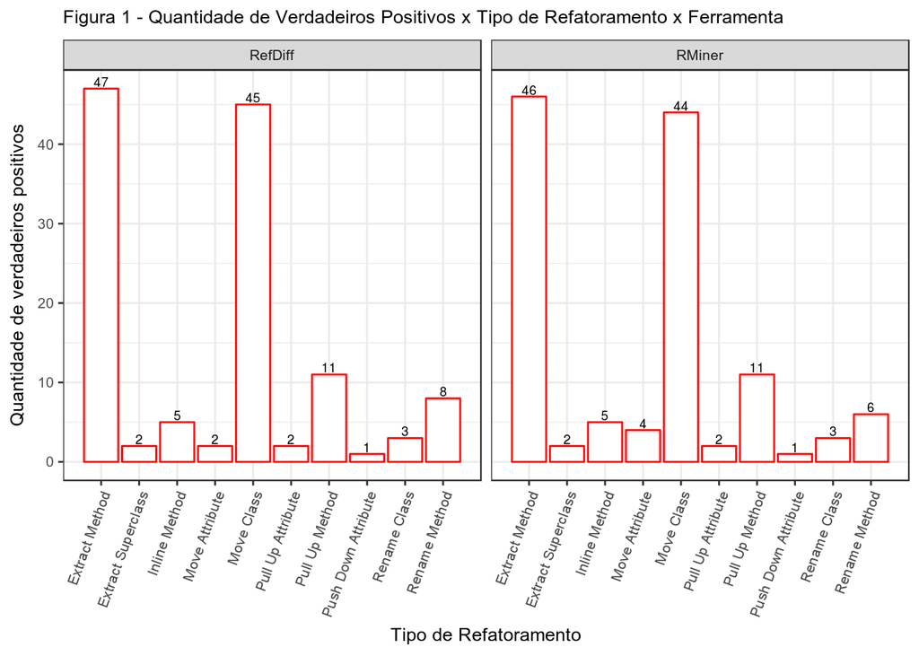

```r
theme_function <- function(){
  theme(text = element_text(family = "Arial", size = 10), plot.title = element_text(size = 10), axis.title.x = element_text(size = 10), axis.title.y = element_text(size = 10))
}

datasetRefactoringsForPlot_function <- function(variable){

  datasetRefactoringsForPlot <- datasetRefactorings %>%
    select(tool, refactoringType, as.character(variable))

  datasetRefactoringsForPlot <- setNames(datasetRefactoringsForPlot,  c("tool", "refactoringType", "variable"))

  datasetRefactoringsForMean <- datasetRefactoringsForPlot %>%
    group_by(tool) %>%
    summarize(meanVariable = mean(variable))

  glimpse(datasetRefactoringsForMean)

  return(datasetRefactoringsForPlot)
}

plot_tp_fp_fnByToolAndRefactoringType_function <- function(variable, plotTitle, ylabTitle){

  datasetRefactoringsForPlot <- datasetRefactoringsForPlot_function(variable)

  datasetRefactoringsForPlot %>%
    ggplot(aes(y = variable, x = refactoringType)) +
    facet_grid(. ~tool) +
    ggtitle(plotTitle) +
    geom_bar(stat = "identity", fill = "white", color = "red") +
    geom_text(aes(label = paste(variable)), size = 2.5, position = position_dodge(width = 2), vjust = -0.2) +
    ylab(ylabTitle) +
    xlab("Tipo de Refatoramento") +
    theme_function() +
    theme(axis.text.x = element_text(angle = 70, hjust = 1))
}

plot_tp_fp_fnByToolAndRefactoringType_function("TP", "Figura 1 - Quantidade de Verdadeiros Positivos x Tipo de Refatoramento x Ferramenta", "Quantidade de verdadeiros positivos")
```

```
## Observations: 2
## Variables: 2
## $ tool         <chr> "RefDiff", "RMiner"
## $ meanVariable <dbl> 0.3, 15.3
```

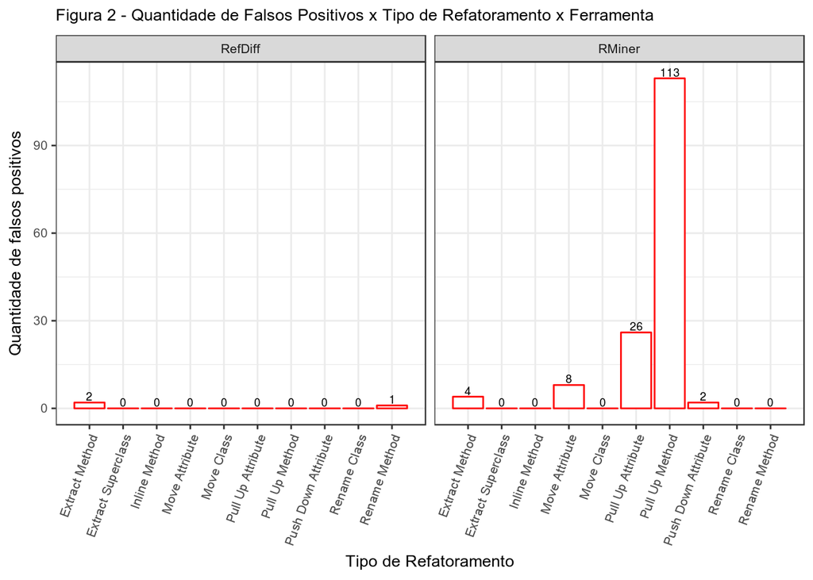

```r
plot_tp_fp_fnByToolAndRefactoringType_function("FP", "Figura 2 - Quantidade de Falsos Positivos x Tipo de Refatoramento x Ferramenta", "Quantidade de falsos positivos")
```

```
## Observations: 2
## Variables: 2
## $ tool         <chr> "RefDiff", "RMiner"
## $ meanVariable <dbl> 0.9, 1.0
```

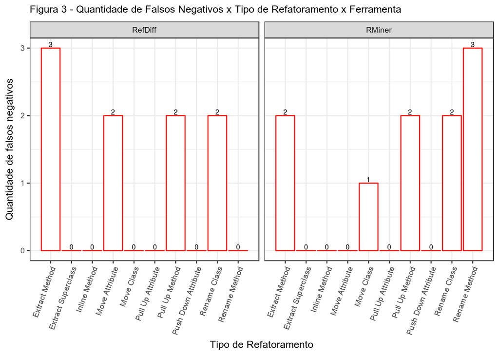

```r
plot_tp_fp_fnByToolAndRefactoringType_function("FN", "Figura 3 - Quantidade de Falsos Negativos x Tipo de Refatoramento x Ferramenta", "Quantidade de falsos negativos")
```

A partir da figura 1, observa-se que, para a amostra, a maioria dos refatoramentos aplicados é do tipo *Extract Method* e *Move Class*. Em média, a quantidade de verdadeiros positivos é 12.6 para o *RefDiff* e 12.4 para o *RMiner*, por tipo de refatoramento.

A figura 2 exibe a distribuição de falsos positivos por tipo de refatoramento. É relevante notar a presença de valores extremos (*outliers*) na detecção dos refatoramentos *Pull Up Attribute* e *Pull Up Method*, pelo *RMiner*. Em média, a quantidade de falsos positivos para o *RefDiff* é 0.3 e 15.3 para o *RMiner*. É possível também observar que há um número maior de falsos positivos nas detecções efetuadas pelo *RMiner* em relação ao *RefDiff*.

A distribuição de falsos negativos é apresentada na figura 3. Em média, 0.9 dos refatoramentos são falsos negativos para o *RefDiff* e 1.0 para o *RMiner*, com divergências em termos do tipo de refatoramento não-detectado.

As figuras 4 a 5 exibem a distribuição da precisão e do *recall* por tipo de refatoramento para o *RefDiff* e *RMiner*.

```
## Observations: 2
## Variables: 2
## $ tool         <chr> "RefDiff", "RMiner"
## $ meanVariable <dbl> 98.48, 81.87
```

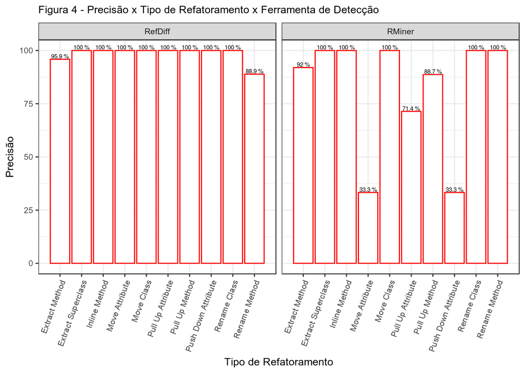

```r
plot_precision_recall_ByToolAndRefactoringType_function <- function(variable, plotTitle, ylabTitle){

  datasetPrecisionAndRecallRefactoringsForPlot <- datasetRefactoringsForPlot_function(variable)

  datasetPrecisionAndRecallRefactoringsForPlot %>%
    ggplot(aes(y = variable, x = refactoringType)) +
    facet_grid(. ~tool) +
    ggtitle(plotTitle) +
    geom_bar(stat = "identity", fill = "white", color = "red") +
    geom_text(aes(label = paste(round(variable, digits = 2), "%")), size = 2, position = position_dodge(width = 2), vjust = -0.2) +
    ylab(ylabTitle) +
    xlab("Tipo de Refatoramento") +
    theme_function() +
    theme(axis.text.x = element_text(angle = 70, hjust = 1))
 }

plot_precision_recall_ByToolAndRefactoringType_function("precision", "Figura 4 - Precisão x Tipo de Refatoramento x Ferramenta de Detecção", "Precisão")
```

```
## Observations: 2
## Variables: 2
## $ tool         <chr> "RefDiff", "RMiner"
## $ meanVariable <dbl> 88.86, 90.49
```

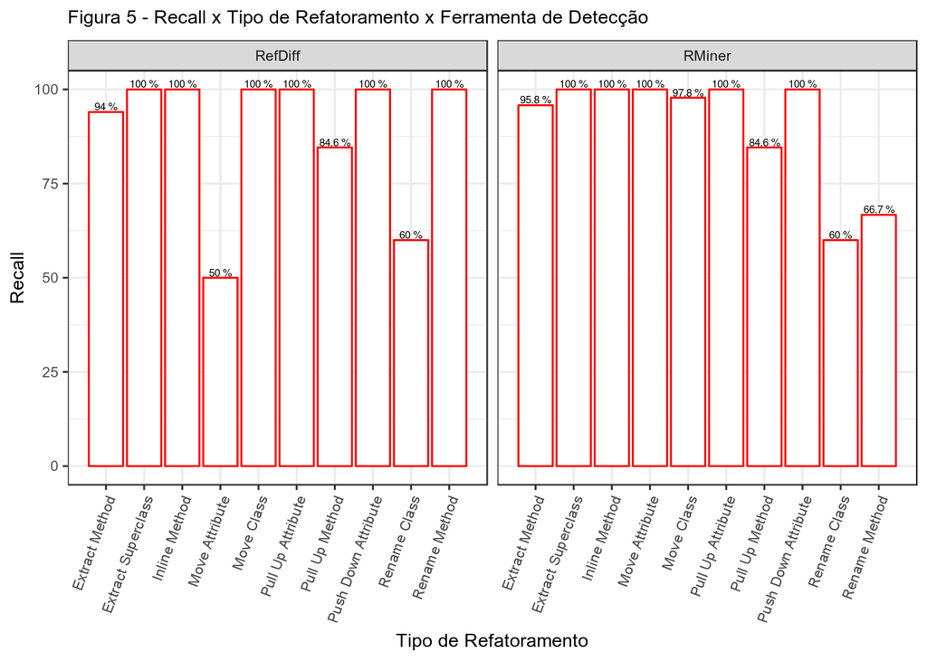

```r
plot_precision_recall_ByToolAndRefactoringType_function("recall", "Figura 5 - Recall x Tipo de Refatoramento x Ferramenta de Detecção", "Recall")
```

De acordo com a figura 4, a precisão das ferramentas *RefDiff* e *RMiner* variam de 88.9% a 100% e de 33.3% a 100%, respectivamente. Em média, a precisão do *RefDiff* (98.5%) é maior que a do *RMiner* (81.9%).

O oposto ocorre em relação ao *recall*, para o qual o *RMiner* (90.5%) é superior, em média, ao *RefDiff* (88.9%). Nestes termos, a figura 5 exibe a distribuição do *recall* para ambas as ferramentas que, por sua vez, varia de 50% a 100% para o *RefDiff* e de 60% a 100%, para o *RMiner*.

A figura 6 exibe a distribuição do tempo de execução dos 37 *commits* em função das ferramentas de detecção de refatoramento, utilizadas na repetição do experimento.

```
## Observations: 37
## Variables: 3
## $ Tool          <chr> "RefDiff", "RefDiff", "RefDiff", "RefDiff", "Ref...
## $ CommitId      <chr> "6cf596df183b3c3a38ed5dd9bb3b0100c6548ebb", "280...
## $ ExecutionTime <dbl> 6095.8, 606.5, 595.9, 1636.6, 683.2, 922.7, 2763...
```

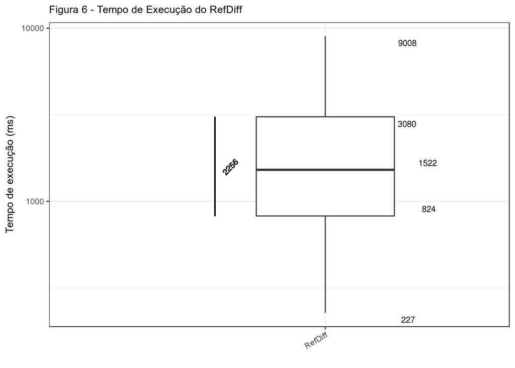

```r
plotExecutionTimeByTool_function <- function(variable, plotTitle){

  datasetExecutionTimeForPlot <- filter(datasetExecutionTime, Tool == as.character(variable))

  glimpse(datasetExecutionTimeForPlot)

  datasetExecutionTimeForPlot %>%
    ggplot(aes(y = ExecutionTime, x = Tool)) +
    geom_boxplot() +
    scale_y_log10() +
    ggtitle(plotTitle) +
    ylab("Tempo de execução (ms)") +
    xlab(" ") +
    theme_function() +
    theme(axis.text.x = element_text(angle = 30, hjust = 1)) +
    geom_text_repel(data = data.frame(q = as.numeric(quantile(datasetExecutionTimeForPlot$ExecutionTime))), aes(x = rep(1.5,5), y = q, label = format(q, digits = 2)), size = 2.9, position = position_dodge(width = 1)) +  # add quantile values
    geom_text(aes(x = 0.5, y = median(datasetExecutionTimeForPlot$ExecutionTime), label = format(quantile(datasetExecutionTimeForPlot$ExecutionTime)[4] - quantile(datasetExecutionTimeForPlot$ExecutionTime)[2], digits = 2), angle = 45), size = 2.9, position = position_dodge(width = 2), vjust = -0.2) + # add interquartile value
    geom_linerange(aes(x = 0.4, ymin = quantile(datasetExecutionTimeForPlot$ExecutionTime)[2], ymax = quantile(datasetExecutionTimeForPlot$ExecutionTime)[4])) # add linerange for interquartile

}

plotExecutionTimeByTool_function("RefDiff", "Figura 6 - Tempo de Execução do RefDiff")
```

```
## Observations: 37
## Variables: 3
## $ Tool          <chr> "RMiner", "RMiner", "RMiner", "RMiner", "RMiner"...
## $ CommitId      <chr> "6cf596df183b3c3a38ed5dd9bb3b0100c6548ebb", "cb4...
## $ ExecutionTime <dbl> 0.20712, 0.00144, 0.00139, 0.00204, 0.00145, 0.0...
```

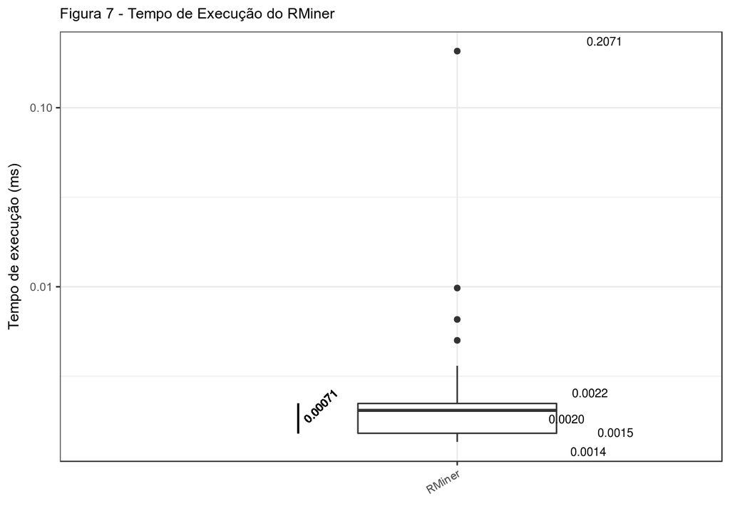

```r
plotExecutionTimeByTool_function("RMiner", "Figura 7 - Tempo de Execução do RMiner")
```

Para a amostra considerada, de acordo com a figura 6, o tempo de execução do *RefDiff* varia de 227 a 9008 ms, com valor mediano de 1522 ms. Sendo assim, em até 50% das detecções, o tempo de execução é menor que 1522 ms e até 75%, é menor que 3080 ms.

Para o *RMiner*, a figura 7 exibe valores (0.0014 a 0.2071 ms) extremamente menores que os valores dos tempos de execução do *RefDiff*, para a mesma amostra de dados. Assim, 50% das detecções foram efetuadas em até 0.002 ms, enquanto 75% delas ocorreram em até 0,0022 ms. Portanto, é possível concluir que o *RMiner* é aproximadamente 760000 vezes mais rápido que o *RefDiff*, para a amostra.

A mediana é a estatística de medida central mais adequada para o contexto e será utilizada na inferência estatística para o tempo de execução, pois não é influenciada por valores extremos.

### **4. Inferência Estatística Aplicada à Detecção de Refatoramentos**

A partir do *dataset* *datasetRefactorings*, é extraída uma amostra de 5 observações para cada ferramenta de detecção e o processo de *bootstraping* é iniciado. As figuras 8 a 11 exibem a distribuição da média da precisão e *recall* para o *RefDiff* e *RMiner*. Em seguida, calcula-se o intervalo de confiança.

```r
##datasets de refatoramentos para cada ferramenta de detecção

datasetRefactoringsRefDiff <- filter(datasetRefactorings, tool == "RefDiff")
glimpse(datasetRefactoringsRefDiff)
```

```
## Observations: 10
## Variables: 7
## $ tool            <chr> "RefDiff", "RefDiff", "RefDiff", "RefDiff", "R...
## $ refactoringType <chr> "Extract Method", "Extract Superclass", "Move ...
## $ TP              <int> 47, 2, 45, 2, 11, 2, 1, 5, 8, 3
## $ FP              <int> 2, 0, 0, 0, 0, 0, 0, 0, 1, 0
## $ FN              <int> 3, 0, 0, 2, 2, 0, 0, 0, 0, 2
## $ precision       <dbl> 95.9, 100.0, 100.0, 100.0, 100.0, 100.0, 100.0...
## $ recall          <dbl> 94.0, 100.0, 100.0, 50.0, 84.6, 100.0, 100.0, ...
```

```r
datasetRefactoringsRMiner <- filter(datasetRefactorings, tool == "RMiner")
glimpse(datasetRefactoringsRMiner)
```

```
## Observations: 10
## Variables: 7
## $ tool            <chr> "RMiner", "RMiner", "RMiner", "RMiner", "RMine...
## $ refactoringType <chr> "Extract Method", "Extract Superclass", "Move ...
## $ TP              <int> 46, 2, 44, 4, 11, 2, 1, 5, 6, 3
## $ FP              <int> 4, 0, 0, 8, 113, 26, 2, 0, 0, 0
## $ FN              <int> 2, 0, 1, 0, 2, 0, 0, 0, 3, 2
## $ precision       <dbl> 92.0, 100.0, 100.0, 33.3, 88.7, 71.4, 33.3, 10...
## $ recall          <dbl> 95.8, 100.0, 97.8, 100.0, 84.6, 100.0, 100.0, ...
```

```r
##iniciando o processo de bootstraping
set.seed(123)    ## semente para a aleatoriedade de amostras

experimentRefDiff = sample_n(datasetRefactoringsRefDiff, 5, replace = TRUE)   ##obtém amostra de tamanho 5
glimpse(experimentRefDiff)
```

```
## Observations: 5
## Variables: 7
## $ tool            <chr> "RefDiff", "RefDiff", "RefDiff", "RefDiff", "R...
## $ refactoringType <chr> "Move Class", "Inline Method", "Pull Up Method...
## $ TP              <int> 45, 5, 11, 8, 3
## $ FP              <int> 0, 0, 0, 1, 0
## $ FN              <int> 0, 0, 2, 0, 2
## $ precision       <dbl> 100.0, 100.0, 100.0, 88.9, 100.0
## $ recall          <dbl> 100.0, 100.0, 84.6, 100.0, 60.0
```

```r
experimentRMiner = sample_n(datasetRefactoringsRMiner, 5, replace = TRUE)
glimpse(experimentRMiner)
```

```
## Observations: 5
## Variables: 7
## $ tool            <chr> "RMiner", "RMiner", "RMiner", "RMiner", "RMiner"
## $ refactoringType <chr> "Extract Method", "Pull Up Attribute", "Rename...
## $ TP              <int> 46, 2, 6, 2, 11
## $ FP              <int> 4, 26, 0, 26, 113
## $ FN              <int> 2, 0, 3, 0, 2
## $ precision       <dbl> 92.0, 71.4, 100.0, 71.4, 88.7
## $ recall          <dbl> 95.8, 100.0, 66.7, 100.0, 84.6
```

```r
bootstrap_function <- function(data, index, variablePrecisionOrRecall){
  meanPrecisionOrRecallByTool = data %>%
      slice(index) %>%       ##reamostragem
      pull(variablePrecisionOrRecall) %>%  ##variável de interesse
      mean()        ##média da precisao ou recall

    return(meanPrecisionOrRecallByTool)
}

plot_precision_and_recall_function <- function(bootstrapsVar, plotTitle, xlabTitle){

  tibble(estatistica = as.double(bootstrapsVar$t)) %>%
    ggplot(aes(x = estatistica)) +
    geom_histogram(fill = "white", color = "red", bins = 10) +
    ggtitle(plotTitle) +
    ylab(" ") +
    xlab(xlabTitle) +
    theme_function() +
    geom_vline(aes(xintercept = mean(estatistica)), color="blue", linetype = "dashed")
}

doBootstraping_function <- function(experiment, variablePrecisionOrRecall, plotTitle, xlabTitle){

  bootstraps <- boot(experiment, bootstrap_function, R = 2000, variablePrecisionOrRecall = variablePrecisionOrRecall)
  print(plot_precision_and_recall_function(bootstraps, plotTitle, xlabTitle))
  print(boot.ci(bootstraps, conf = 0.95, type = "perc"))
}
```

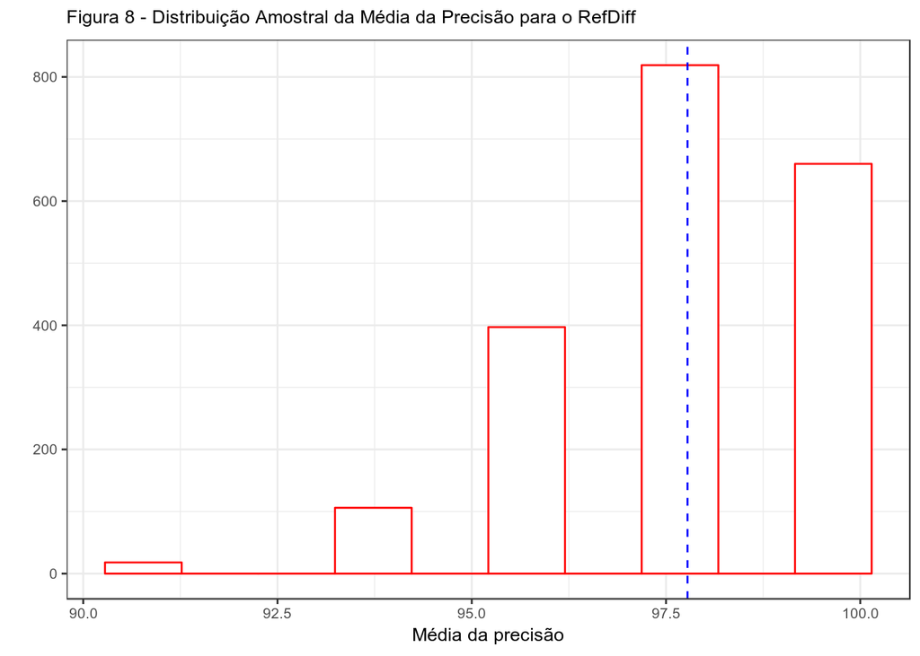

```
## BOOTSTRAP CONFIDENCE INTERVAL CALCULATIONS
## Based on 2000 bootstrap replicates
##
## CALL :
## boot.ci(boot.out = bootstraps, conf = 0.95, type = "perc")
##
## Intervals :
## Level     Percentile
## 95%   ( 93.34, 100.00 )
## Calculations and Intervals on Original Scale
```

```r
doBootstraping_function(experimentRefDiff, "precision", "Figura 8 - Distribuição Amostral da Média da Precisão para o RefDiff", "Média da precisão")
```

Afirma-se com 95% de confiança que a média geral da precisão para o *RefDiff* está entre 93.34 a 100%.

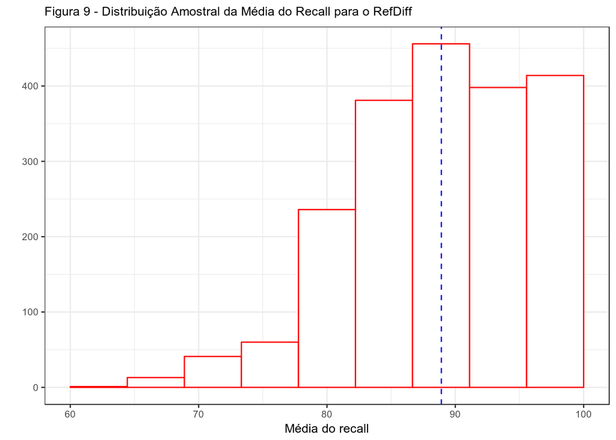

```
## BOOTSTRAP CONFIDENCE INTERVAL CALCULATIONS
## Based on 2000 bootstrap replicates
##
## CALL :
## boot.ci(boot.out = bootstraps, conf = 0.95, type = "perc")
##
## Intervals :
## Level     Percentile
## 95%   ( 72.92, 100.00 )
## Calculations and Intervals on Original Scale
```

```r
doBootstraping_function(experimentRefDiff, "recall", "Figura 9 - Distribuição Amostral da Média do Recall para o RefDiff", "Média do recall")
```

Com 95% de confiança, conclui-se que a média geral do *recall* para o *RefDiff* está entre 72.92 a 100%.

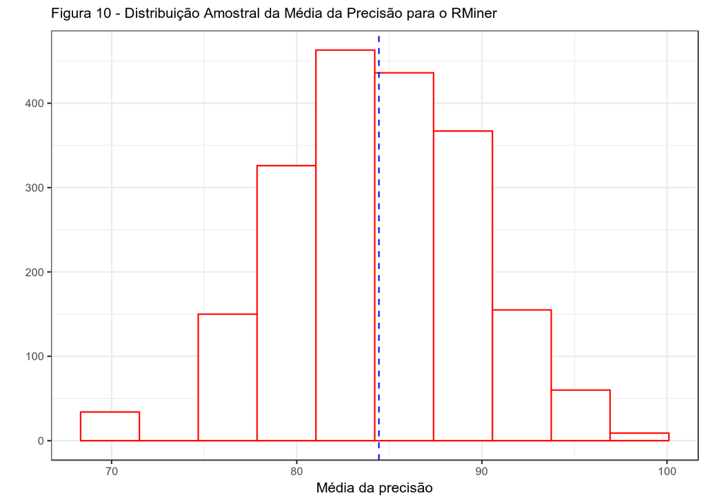

```
## BOOTSTRAP CONFIDENCE INTERVAL CALCULATIONS
## Based on 2000 bootstrap replicates
##
## CALL :
## boot.ci(boot.out = bootstraps, conf = 0.95, type = "perc")
##
## Intervals :
## Level     Percentile
## 95%   (74.86, 94.28 )
## Calculations and Intervals on Original Scale
```

```r
doBootstraping_function(experimentRMiner, "precision", "Figura 10 - Distribuição Amostral da Média da Precisão para o RMiner", "Média da precisão")
```

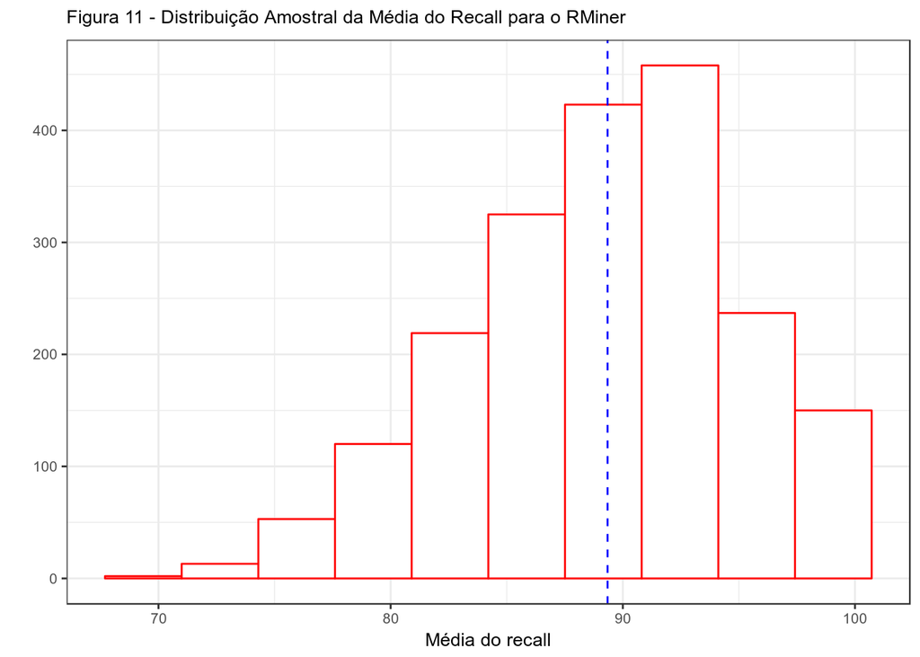

```
## BOOTSTRAP CONFIDENCE INTERVAL CALCULATIONS
## Based on 2000 bootstrap replicates
##
## CALL :
## boot.ci(boot.out = bootstraps, conf = 0.95, type = "perc")
##
## Intervals :
## Level     Percentile
## 95%   (76.94, 99.16 )
## Calculations and Intervals on Original Scale
```

```r
doBootstraping_function(experimentRMiner, "recall", "Figura 11 - Distribuição Amostral da Média do Recall para o RMiner", "Média do recall")
```

### **5. Inferência Estatística baseada em Teste de Hipótese Aplicada ao Tempo de Detecção de Refatoramentos**

Os seguintes passos são propostos para a realização do teste de hipótese para o tempo de execução do *RefDiff* e *RMiner* durante a detecção de refatoramentos em 37 *commits*:

- Estabelecimento das hipóteses nula (H<sub>0</sub>) e alternativa (H<sub>a</sub>);
- Determinação do nível de significância do teste (α);
- Cálculo da estatística de teste a partir das observações;
- Cálculo do p-valor e teste de Wilcoxon.

#### **Estabelencendo as hipóteses nula e alternativa**

- H<sub>0</sub>: O tipo de ferramenta de detecção não influencia o tempo de execução;
- H<sub>a</sub>: O tipo de ferramenta de detecção influencia o tempo de execução.

#### **Determinando o nível de significância do teste**

Considera-se um nível de confiança (γ) de 0,95, isto é, 95% de probabilidade de não rejeitar a hipótese nula, quando ela é verdadeira. Sendo assim, o nível de significância é 0,05 (γ = 1 - α), o que representa a probabilidade de 5% de rejeitar a hipótese nula quando esta for verdadeira.

#### **Calculando a estatística de teste**

A **mediana** do tempo de execução é a estatística considerada para fins de inferência estatística.

```r
executionTimeByTool = datasetExecutionTime %>%
  group_by(Tool) %>%
  summarize(medianExecutionTime = median(ExecutionTime))

glimpse(executionTimeByTool)
```

```
## Observations: 2
## Variables: 2
## $ Tool                <chr> "RefDiff", "RMiner"
## $ medianExecutionTime <dbl> 1522.30000, 0.00204
```

##### **Calculando o p-valor e efetuando o teste de Wilcoxon**

```r
##efetuando o cálculo do p-valor
permutationTest2(datasetExecutionTime, median(ExecutionTime), treatment = Tool)
```

```
## Call:
## permutationTest2(data = datasetExecutionTime, statistic = median(ExecutionTime),
##     treatment = Tool)
## Replications: 9999
## Two samples, sample sizes are 37 37
##
## Summary Statistics for the difference between samples 1 and 2:
##                                       Observed     Mean Alternative PValue
## median(ExecutionTime): RefDiff-RMiner 1522.298 2.953942   two.sided  2e-04
```

```r
permutationTest2(datasetExecutionTime, mean(ExecutionTime), treatment = Tool)
```

```
## Call:
## permutationTest2(data = datasetExecutionTime, statistic = mean(ExecutionTime),
##     treatment = Tool)
## Replications: 9999
## Two samples, sample sizes are 37 37
##
## Summary Statistics for the difference between samples 1 and 2:
##                                     Observed      Mean Alternative PValue
## mean(ExecutionTime): RefDiff-RMiner 2396.365 -1.694051   two.sided  2e-04
```

```r
wilcox_test(ExecutionTime ~ as.factor(Tool),
            data = datasetExecutionTime,
            distribution = "exact", paired = TRUE)
```

```
##
##  Exact Wilcoxon-Mann-Whitney Test
##
## data:  ExecutionTime by as.factor(Tool) (RefDiff, RMiner)
## Z = 7.4002, p-value < 2.2e-16
## alternative hypothesis: true mu is not equal to 0
```

O p-valor calculado é aproximadamente 0.0002, para a mediana (obtém-se o mesmo resultado para a média, exibida aqui apenas para fins de comparação entre as estatísticas).

A partir do resultado do teste de Wilcoxon, é possível afirmar com 95% que a hipótese nula pode ser rejeitada, com p-valor igual a 2.2 * 10<sup>-16</sup>.